# Insurance Data set

```python
import pandas as pd
```

```python
df=pd.read_csv('insurance.csv')
```

```python
df
```

|  | age | sex | bmi | children | smoker | region | charges |
| --- | --- | --- | --- | --- | --- | --- | --- |
| 0 | 19 | female | 27.900 | 0 | yes | southwest | 16884.92400 |
| 1 | 18 | male | 33.770 | 1 | no | southeast | 1725.55230 |
| 2 | 28 | male | 33.000 | 3 | no | southeast | 4449.46200 |
| 3 | 33 | male | 22.705 | 0 | no | northwest | 21984.47061 |
| 4 | 32 | male | 28.880 | 0 | no | northwest | 3866.85520 |
| ... | ... | ... | ... | ... | ... | ... | ... |
| 1333 | 50 | male | 30.970 | 3 | no | northwest | 10600.54830 |
| 1334 | 18 | female | 31.920 | 0 | no | northeast | 2205.98080 |
| 1335 | 18 | female | 36.850 | 0 | no | southeast | 1629.83350 |
| 1336 | 21 | female | 25.800 | 0 | no | southwest | 2007.94500 |
| 1337 | 61 | female | 29.070 | 0 | yes | northwest | 29141.36030 |

1338 rows × 7 columns

```python
df.describe()
```

|  | age | bmi | children | charges |
| --- | --- | --- | --- | --- |
| count | 1338.000000 | 1338.000000 | 1338.000000 | 1338.000000 |
| mean | 39.207025 | 30.663397 | 1.094918 | 13270.422265 |
| std | 14.049960 | 6.098187 | 1.205493 | 12110.011237 |
| min | 18.000000 | 15.960000 | 0.000000 | 1121.873900 |
| 25% | 27.000000 | 26.296250 | 0.000000 | 4740.287150 |
| 50% | 39.000000 | 30.400000 | 1.000000 | 9382.033000 |
| 75% | 51.000000 | 34.693750 | 2.000000 | 16639.912515 |
| max | 64.000000 | 53.130000 | 5.000000 | 63770.428010 |

```python
df.info()
```

```
<class 'pandas.core.frame.DataFrame'>
RangeIndex: 1338 entries, 0 to 1337
Data columns (total 7 columns):
 #   Column    Non-Null Count  Dtype
---  ------    --------------  -----
 0   age       1338 non-null   int64
 1   sex       1338 non-null   object
 2   bmi       1338 non-null   float64
 3   children  1338 non-null   int64
 4   smoker    1338 non-null   object
 5   region    1338 non-null   object
 6   charges   1338 non-null   float64
dtypes: float64(2), int64(2), object(3)
memory usage: 73.3+ KB
```

```python
df.shape
```

```
(1338, 7)
```

Checking Data type of each Attribute

```python
df.dtypes
```

```
age           int64
sex          object
bmi         float64
children      int64
smoker       object
region       object
charges     float64
dtype: object
```

Checking for null values

```python
df.isnull().sum()
```

```
age         0
sex         0
bmi         0
children    0
smoker      0
region      0
charges     0
dtype: int64
```

Identifying numerical Attributes

```python
int_attributes=df.select_dtypes(include='int64').columns.tolist()
float_attributes=df.select_dtypes(include='float64').columns.tolist()
print(int_attributes, float_attributes)
```

```
['age', 'children'] ['bmi', 'charges']
```

```python
import matplotlib.pyplot as plt
import seaborn as sns
import numpy as np
```

5 point summary of Numberical Attributes

```
Minimum at: 18
25 % Quarantile starts at: 27.0
Median at: 39.0
75 % Quarantile ends at: 51.0
Maximum at: 64
```

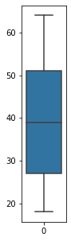

```python
plt.figure(num=1, figsize=(1,5))
box_age=sns.boxplot(data=df.age)
print("Minimum at:",np.min(df.age))
print("25 % Quarantile starts at:", np.percentile(df.age,25))
print("Median at:",np.median(df.age))
print("75 % Quarantile ends at:", np.percentile(df.age,75))
print("Maximum at:",np.max(df.age))
```

No outliers are observed, which tells us there are neither too young nor too old people are having Insurance policy.

```
Minimum at: 0
25 % Quarantile starts at: 0.0
Median at: 1.0
75 % Quarantile ends at: 2.0
Maximum at: 5
```

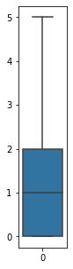

```python
plt.figure(num=1,figsize=(1,5))
box_childern=sns.boxplot(data=df.children)
print("Minimum at:",np.min(df.children))
print("25 % Quarantile starts at:", np.percentile(df.children,25))
print("Median at:",np.median(df.children))
print("75 % Quarantile ends at:", np.percentile(df.children,75))
print("Maximum at:",np.max(df.children))
```

No outliers are observed.

```
Minimum at: 15.96
25 % Quarantile starts at: 26.29625
Median at: 30.4
75 % Quarantile ends at: 34.69375
Maximum at: 53.13
```

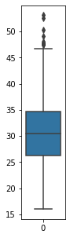

```python
# Ideal BMI range is 18.4 to 24.9

plt.figure(num=1,figsize=(1,5))
box_bmi=sns.boxplot(data=df.bmi)
print("Minimum at:",np.min(df.bmi))
print("25 % Quarantile starts at:", np.percentile(df.bmi,25))
print("Median at:",np.median(df.bmi))
print("75 % Quarantile ends at:", np.percentile(df.bmi,75))
print("Maximum at:",np.max(df.bmi))
```

Few outliers are observed, indicating their health risk might increase significantly.

```
Minimum at: 1121.8739
25 % Quarantile starts at: 4740.28715
Median at: 9382.033
75 % Quarantile ends at: 16639.912515
Maximum at: 63770.42801
```

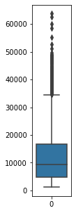

```python
plt.figure(num=1,figsize=(1,5))
box_charges=sns.boxplot(data=df.charges)
print("Minimum at:",np.min(df.charges))
print("25 % Quarantile starts at:", np.percentile(df.charges,25))
print("Median at:",np.median(df.charges))
print("75 % Quarantile ends at:", np.percentile(df.charges,75))
print("Maximum at:",np.max(df.charges))
```

Potential outliers are observed in Charges column, which tells us many Policy holders have severe pre-existing diseases.

```python
import warnings
warnings.filterwarnings('ignore')
```

Distribution plots for numerical Attributes

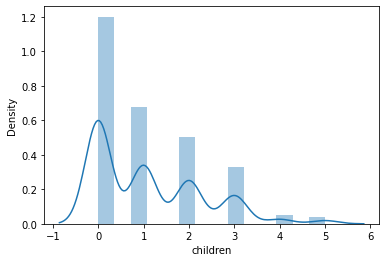

```python
sns.distplot(df['children'])
```

Policy holders with zero dependents are more followed by one dependent, two dependent and so on. No policy holder is having more than 5 dependents.

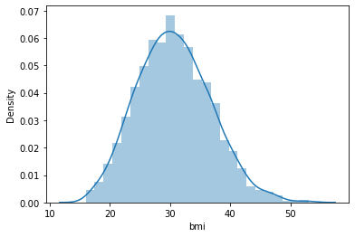

```python
sns.distplot(df['bmi'])
```

BMI of all the policy holders is normally distributed, some of the Policy holders have BMI abnormally high which is indicated on the right side of distribution plot.

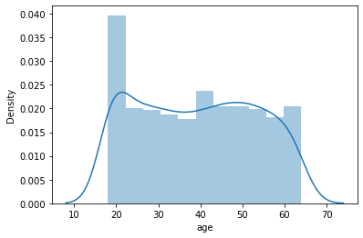

```python
sns.distplot(df["age"])
```

The distribution is Right skewed. Many of the Policy holders are adults. Number of Policy holders from other age group are comparitively same.

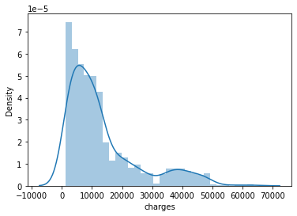

```python
sns.distplot(df['charges'])
```

The distribution is right skewed. Most of the Policy holders are health. A good number of Policy holders are having pre-existing deseases which is the reason for having high medical charges.

```python
df.skew()
```

```
age         0.055673
bmi         0.284047
children    0.938380
charges     1.515880
dtype: float64
```

Measuring Skewness

```python
if(np.mean(df.bmi)>np.median(df.bmi)):
    print('Right Skewed','\n')
else:
    print('Left Skewed','\n')
print("Skewness value of bmi: ",df.bmi.skew())
```

```
Right Skewed

Skewness value of bmi:  0.2840471105987448
```

BMI is Normally distributed but because of Outliers the Mean is shifted towards right which is resulted in little skewness towards right.

```python
if(np.mean(df.age)>np.median(df.age)):
    print('Right Skewed','\n')
else:
    print('Left Skewed','\n')
print("Skewness value of age: ",df.age.skew())
```

```
Right Skewed

Skewness value of age:  0.05567251565299186
```

Most of the Policy holders are Adults but since the Policy holders age group is having larger range, the Mean is shifted right and hence the right skewness.

```python
if(np.mean(df.charges)>np.median(df.charges)):
    print('Right Skewed','\n')
else:
    print('Left Skewed','\n')
print("Skewness value of charges: ",df.charges.skew())
```

```
Right Skewed

Skewness value of charges:  1.5158796580240388
```

Most of the Policy holders are Healthy but since large number of Policy holders are having pre-existing diseases their Medical Charges are more which again effects the mean and so is the Right Skewness.

Counting the number of Outliers in Numeric Attributes

```
Upper potential outliers lies above 47.290000000000006
Lower potential outliers lies below/at 13.7
No. of Potential upper outliers:  9
No. of Potential lower outliers:  0
```

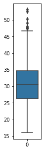

```python
plt.figure(num=1,figsize=(1,5))
sns.boxplot(data=df.bmi)
IQR=np.percentile(df.bmi,75)-np.percentile(df.bmi,25)
upper_outlier=np.percentile(df.bmi,75)+1.5*IQR
print("Upper potential outliers lies above",upper_outlier)
lower_outlier=np.percentile(df.bmi,25)-1.5*IQR
print("Lower potential outliers lies below/at",0 if lower_outlier < 0 else lower_outlier)
print("No. of Potential upper outliers: ",len([i for i in df.bmi if i >= upper_outlier]))
print("No. of Potential lower outliers: ",len([i for i in df.bmi if i <= lower_outlier]))
```

```
Upper potential outliers lies above 87.0
Lower potential outliers lies below/at 0
No. of Potential upper outliers:  0
No. of Potential lower outliers:  0
```

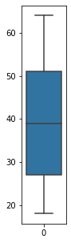

```python
plt.figure(num=1,figsize=(1,5))
sns.boxplot(data=df.age)
IQR=np.percentile(df.age,75)-np.percentile(df.age,25)
upper_outlier=np.percentile(df.age,75)+1.5*IQR
print("Upper potential outliers lies above",upper_outlier)
lower_outlier=np.percentile(df.age,25)-1.5*IQR
print("Lower potential outliers lies below/at",0 if lower_outlier < 0 else lower_outlier)
print("No. of Potential upper outliers: ",len([i for i in df.age if i >= upper_outlier]))
print("No. of Potential lower outliers: ",len([i for i in df.age if i <= lower_outlier]))
```

```
Upper potential outliers lies above 34489.350562499996
Lower potential outliers lies below/at 0
No. of Potential upper outliers:  139
No. of Potential lower outliers:  0
```

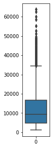

```python
plt.figure(num=1,figsize=(1,5))
sns.boxplot(data=df.charges)
IQR=np.percentile(df.charges,75)-np.percentile(df.charges,25)
upper_outlier=np.percentile(df.charges,75)+(1.5*IQR)
print("Upper potential outliers lies above",upper_outlier)
lower_outlier=np.percentile(df.charges,25)-(1.5*IQR)
print("Lower potential outliers lies below/at",0 if lower_outlier < 0 else lower_outlier)
print("No. of Potential upper outliers: ",len([i for i in df.charges if i > upper_outlier]))
print("No. of Potential lower outliers: ",len([i for i in df.charges if i < lower_outlier]))
```

Out of 1338 Policy holders 139 policy holders are having severe pre-existing diseases.

Identifying Categorical Attributes

```python
categ_attributes=df.select_dtypes(include='object').columns.tolist()
print(categ_attributes)
```

```
['sex', 'smoker', 'region']
```

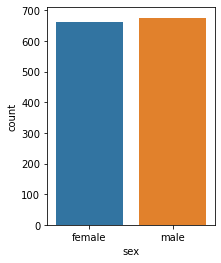

```python
plt.figure(num=1,figsize=(3,4))
sns.countplot(x='sex',data=df)
plt.show()
```

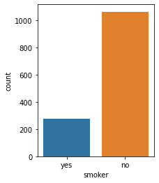

```python
plt.figure(num=1,figsize=(3,4))
sns.countplot(x='smoker',data=df)
plt.show()
```

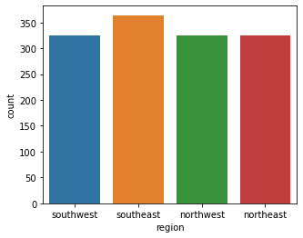

```python
plt.figure(num=1,figsize=(5,4))
sns.countplot(x='region',data=df)
plt.show()
```

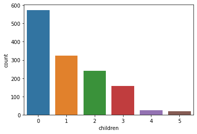

```python
plt.figure(num=1,figsize=(6,4))
sns.countplot(x='children',data=df)
plt.show()
```

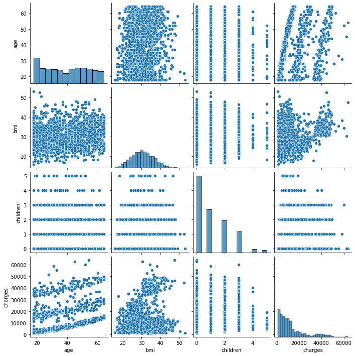

```python
sns.pairplot(df)
```

```python
import scipy.stats as stats
from scipy.stats import ttest_1samp, ttest_ind, wilcoxon
from statsmodels.stats.power import ttest_power
```

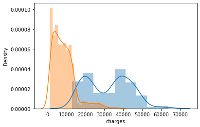

```python
smoker = df[df['smoker']=='yes']['charges']
nonsmoker= df[df['smoker']=='no']['charges']
sns.distplot(smoker)
sns.distplot(nonsmoker)
```

Statistically determine whether Charges for Smokers and Nonsmokers are significantly different or not. Charges is Numerical variable and Smoker is Categorical variable. Smokers and Nonsmokers are two independent samples(a smoker cannot be a nonsmoker at the same time). Using two sample t-test

H0 : Charges of smoker doesn't differ significantly from charges of non smoker. HA : Charges of smoker differ significantly from charges of non-smoker. Here we fix level of significance as α = 0.05.

Alternative hypothesis starts from the view of what statistician is going to prove, here we are trying to prove Charges of smoker differ significantly from charges of non-smoker.

```python
stats.ttest_ind(smoker,nonsmoker)
```

```
Ttest_indResult(statistic=46.66492117272371, pvalue=8.271435842179102e-283)
```

p-value is less than level of significance, hence reject Null hypothesis, which means alternative hypothesis is true, hence Charges of smoker differ significantly from charges of non-smoker.

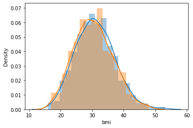

```python
male = df[df['sex']=='male']['bmi']
female = df[df['sex']=='female']['bmi']
sns.distplot(male)
sns.distplot(female)
```

Statistically determine whether BMI of Males and Females are significantly different or not. BMI is Numerical variable and Sex is Categorical variable. Using two sample t-test.

H0 : BMI of Male and Female are not significantly different. HA : BMI of Male and Female are significantly different. level of significance as α = 0.05.

```python
stats.ttest_ind(male,female)
```

```
Ttest_indResult(statistic=1.696752635752224, pvalue=0.08997637178984932)
```

p-value is greater than level of significance, hence do not reject Null hypothesis, hence BMI of Male is not so different from Female.

```python
crosst=pd.crosstab(df['sex'],df['smoker'])
crosst
```

| smoker sex | no | yes |
| --- | --- | --- |
| female | 547 | 115 |
| male | 517 | 159 |

```python
from scipy.stats import f_oneway
```

Using Chi_square test to check if Smoker proportion is significanty different for different Genders. Smoker and Sex are Categorical variables

H0 : The proportion of smokers aren't significantly different in different genders. HA : The proportion of smokers significantly different in different genders.

```python
chi2,pval,dof,expected = stats.chi2_contingency(crosst)
pval
```

```
0.006548143503580696
```

p-value is less than level of significance, hence reject Null hypothesis, which means Alternative hypothesis is true, hence the proportion of smokers significantly different in different genders.

```python
female=df[df['sex']=='female']
female_0=female[female.children==0]['bmi']
female_1=female[female.children==1]['bmi']
female_2=female[female.children==2]['bmi']
```

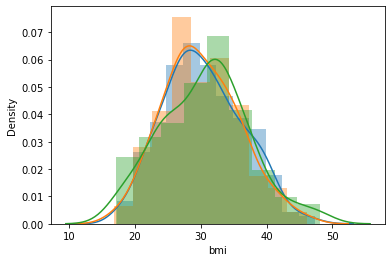

```python
sns.distplot(female_0)
sns.distplot(female_1)
sns.distplot(female_2)
```

To check if the distribution of BMI across Female with zero, one, two childers respectively is same or not. BMI is Numeric variable Female with zero, one, two childern are there columns, it is Numeric variable

H0 : Distribution of BMI across women with no children, one child and two children, are same. HA : Distribution of BMI across women with no children, one child and two children, are not same. level of significance as α = 0.05.

Using ANOVA since there are more than two columns to be compared.

```python
f_oneway(female_0,female_1,female_2)
```

```
F_onewayResult(statistic=0.3344720147757968, pvalue=0.7158579926754841)
```

p-value is greater than level of significance, hence do not reject Null hypothesis, hence Distribution of BMI across women with no children, one child and two children, are same.